# The BUGS language

NIMBLE training materials module

NIMBLE Development Team

# The BUGS language

The BUGS language is described in detail in the [relevant section of the BUGS manual](http://www.openbugs.net/Manuals/ModelSpecification.html).

### Stochastic declarations:

- `x ~ dgamma(shape, scale)` (x follows a gamma distribution with parameters `shape` and `scale`)

### Deterministic declarations

- `y <- 2 * x`

### For loops

- `for(i in 1:10) {x[i] <- exp(y[i])}`

### Classic BUGS examples

There are lots of example models originally provided by the BUGS project:

- included in NIMBLE or found here on the [JAGS website](https://sourceforge.net/projects/mcmc-jags/files/Examples/).
- Information: [Volume 1](http://www.mrc-bsu.cam.ac.uk/wp-content/uploads/WinBUGS_Vol1.pdf), [Volume 2](http://www.mrc-bsu.cam.ac.uk/wp-content/uploads/WinBUGS_Vol2.pdf), and [Volume 3](http://www.mrc-bsu.cam.ac.uk/wp-content/uploads/WinBUGS_Vol3.pdf) of the WinBUGS example manuals.

### NIMBLE’s dialect of BUGS :

- Differences between BUGS syntax for specifying models in NIMBLE and WinBUGS, OpenBUGS and/or JAGS will be covered later.
- Also described in Section 5 of the [NIMBLE Users Manual](http://r-nimble.org/manuals/NimbleUserManual.pdf).

# A basic example

We’ll use the *pump* model example from the original BUGS software. The data set describes the failure rates of some pumps.

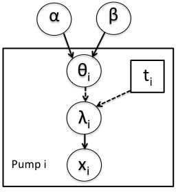

In this model, there are $N=10$ pumps. The number of failures, $x_i$, for pump $i$ is assumed to follow a Poisson distribution, with mean $\lambda_i = \theta_i \cdot t_i$ where $t_i$ is the length of operation of the pump in thousands of hours and $\theta_i$ is the failure rate. The model then borrows strength across pumps with a prior that ties the random effects together using a common distribution, $\theta_i \sim \mbox{Gamma}(\alpha, \beta)$. $\alpha$ and $\beta$ are the hyperparameters of this random effects distribution.

# Specifying the BUGS code for a model

Here we specify the pump code directly in R. We can walk through some of details via the comments in the BUGS code.

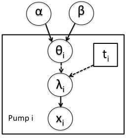

```r
library(nimble)
pumpCode <- nimbleCode({
  for (i in 1:N){

      # likelihood (data model)
      x[i] ~ dpois(lambda[i])

      # latent process (random effects)
      # linear predictor
      lambda[i] <- theta[i]*t[i]
      # random effects distribution
      theta[i] ~ dgamma(alpha,beta)
  }
  # priors on hyperparameters
  alpha ~ dexp(1.0)
  beta ~ dgamma(0.1,1.0)
})
```